# Bias and Normality of Thompson Sampling based algorithms

Sandeep Gangarapu

Concusions:

Mean estimates of MAB and AB behave as intended for both Best and Worst arms.

**We are sampling from 2 arms with distributions of N(2,1) - the worst arm and N(3,1) the best arm.**

# Bias

We expect sample mean estimate of *best* arm for MAB algorithms to be unbiased and drawn from Normal distribution

We expect sample mean estimate of *worst* arm for MAB algorithms to be biased and not drawn from Normal distribution

We expect sample mean estimate of *worst* arm for *AB* to be unbiased and drawn from Normal distribution

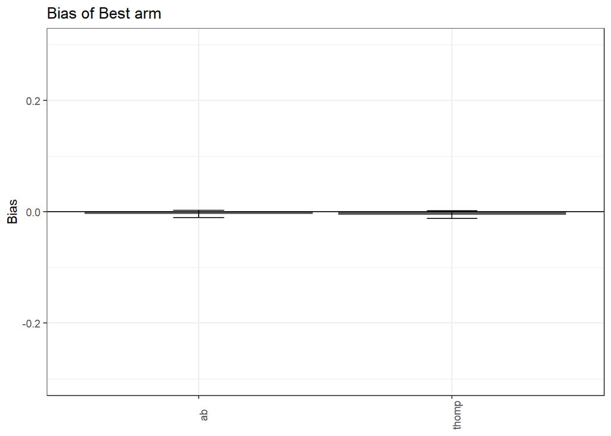

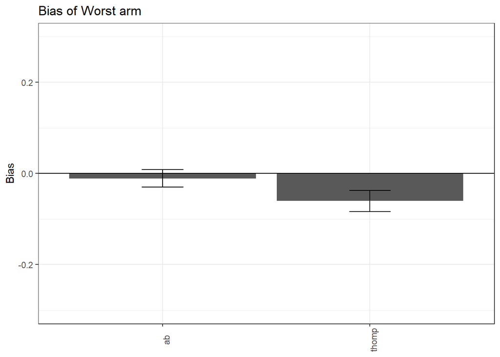

This is as expected. Thompson sampling, a MAB algorithms has a negative bias for its sample mean estimate of the worst arm.

# Normality

We Expect

- AB Testing - Best - Normal
- AB Testing - Worst - Normal
- Thompson Sampling - Best - Normal
- Thompson Sampling - Worst - Not Normal

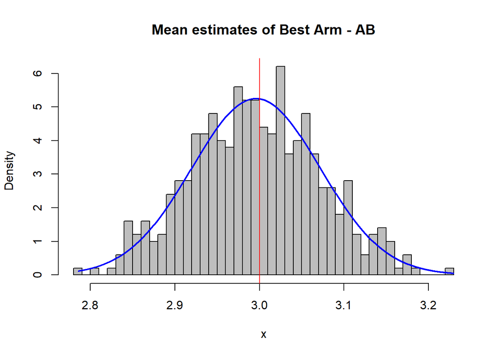

```
##
##  Shapiro-Wilk normality test
##
## data:  best_ab$mn
## W = 0.99742, p-value = 0.6332
```

Sample mean estimate of the best arm for AB testing follows Normal distribution.

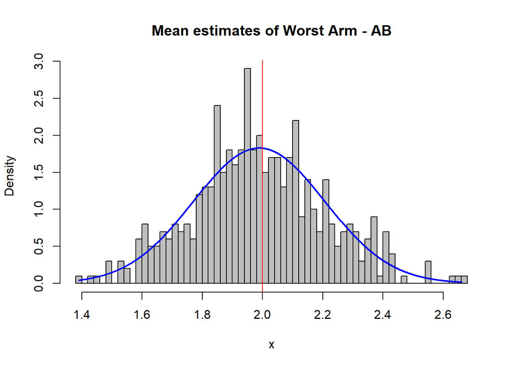

```
##
##  Shapiro-Wilk normality test
##
## data:  worst_ab$mn
## W = 0.9965, p-value = 0.3476
```

Sample mean estimate of the worst arm for AB testing follows Normal distribution.

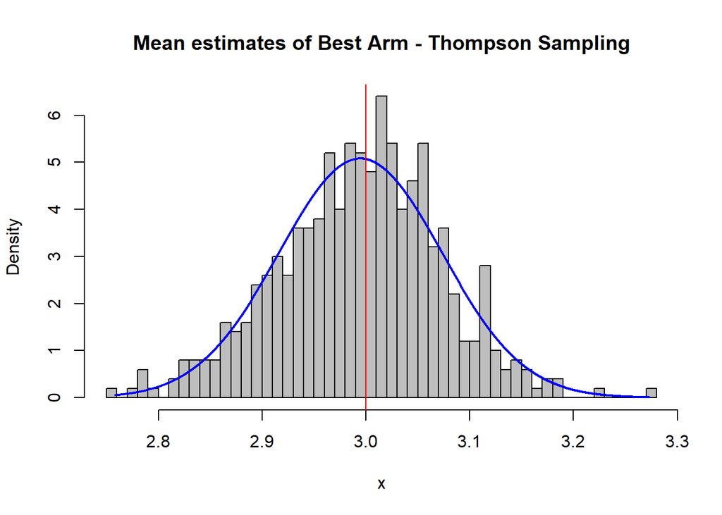

```
##
##  Shapiro-Wilk normality test
##
## data:  best_thomp$mn
## W = 0.99651, p-value = 0.3494
```

Sample mean estimate of the best arm for Thompson Sampling follows Normal distribution.

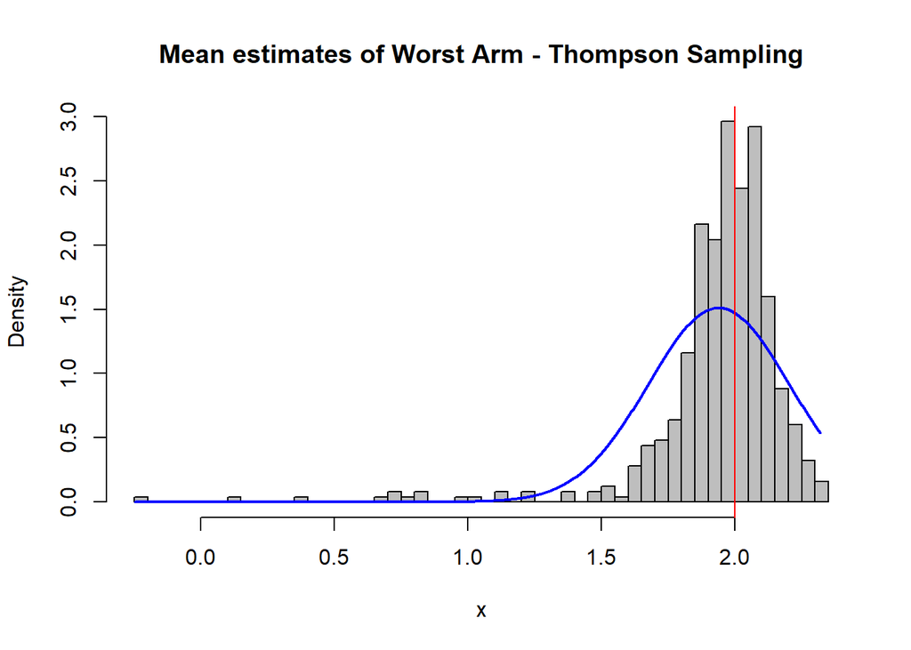

```
##
##  Shapiro-Wilk normality test
##
## data:  worst_thomp$mn
## W = 0.69077, p-value < 2.2e-16
```

Sample mean estimate of the worst arm for Thompson Sampling does not follow Normal distribution.

# Bias and Normality of Thompson INF

We expect the algorithm to be

- Thompson INF - Best arm - Unbiased and Normal
- Thompson INF - Worst arm - Biased and Not Normal

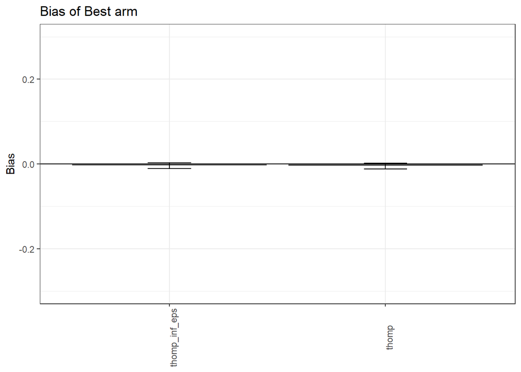

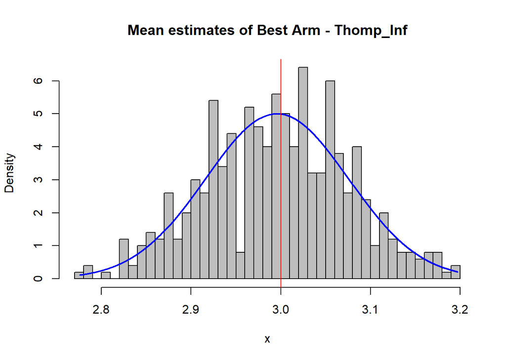

```
##
##  Shapiro-Wilk normality test
##
## data:  best_thomp_inf_eps$mn
## W = 0.99626, p-value = 0.2909
```

Sample mean estimate of the best arm for Thompson INF follows Normal distribution and is unbiased.

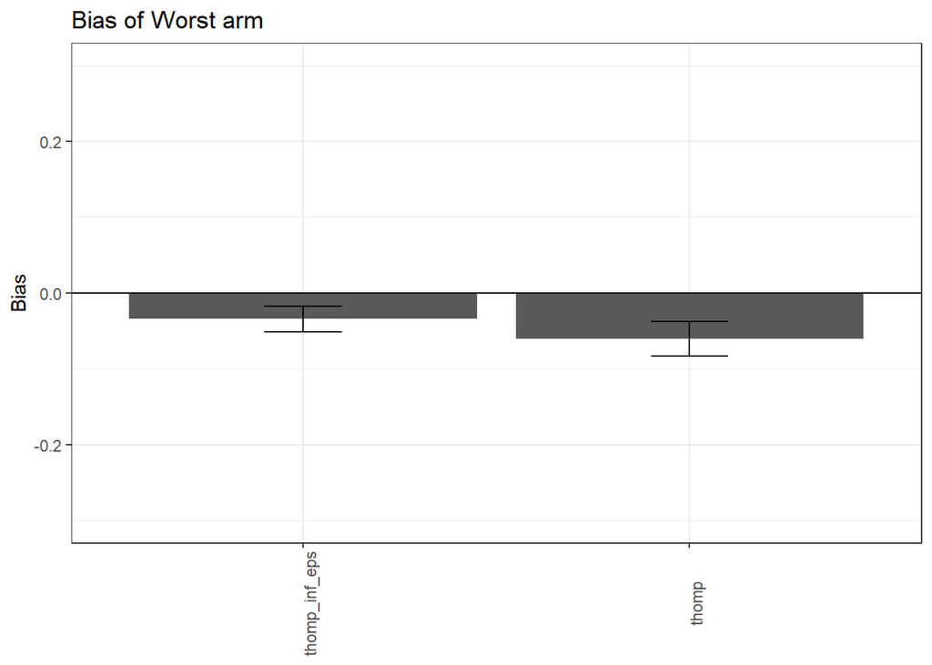

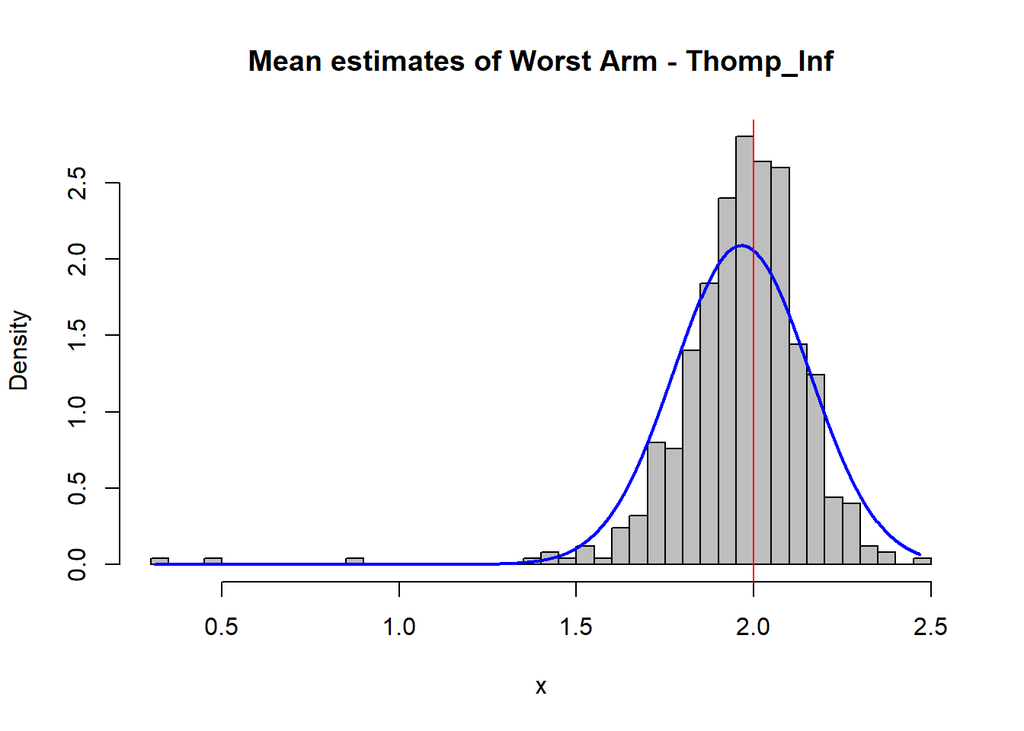

```
##
##  Shapiro-Wilk normality test
##
## data:  worst_thomp_inf_eps$mn
## W = 0.83208, p-value < 2.2e-16
```

Sample mean estimate of the worst arm for Thompson INF does not follow Normal distribution and is biased.

**The variance of the estimate is lower comapared to the original algorithm**

# Weighed estimators

We use IPW and AIPW estimators. We expect that the estimates will be unbiased but not sure about the normality of the estimates.

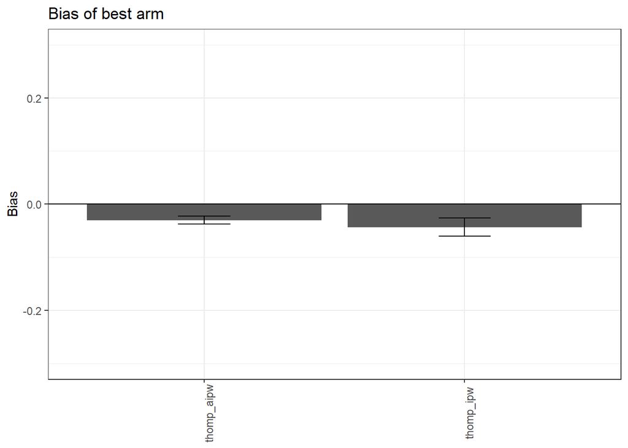

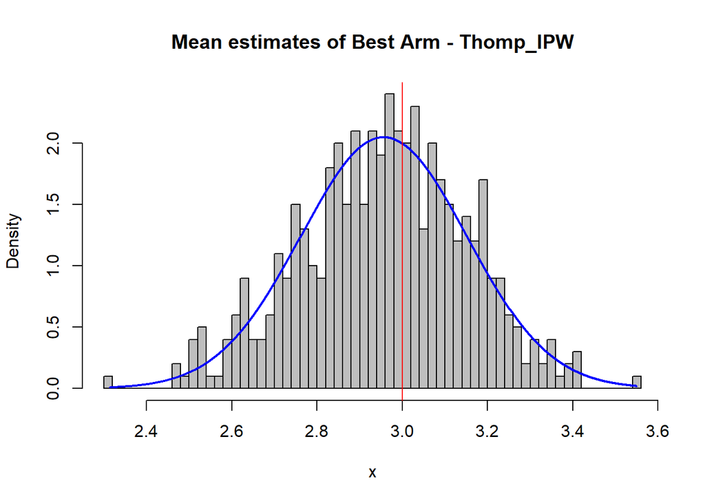

```
##
##  Shapiro-Wilk normality test
##
## data:  best_thomp_ipw$mn
## W = 0.99702, p-value = 0.4987
```

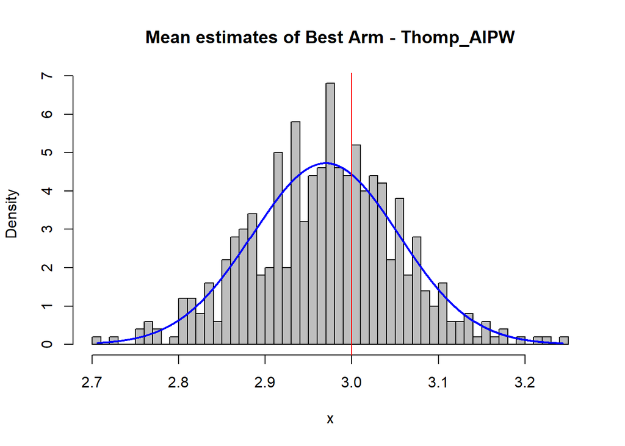

```
##
##  Shapiro-Wilk normality test
##
## data:  best_thomp_aipw$mn
## W = 0.99734, p-value = 0.605
```

**For some reason, the weighed estimators of the best arm are negatively biased** but the normality is still maintained.

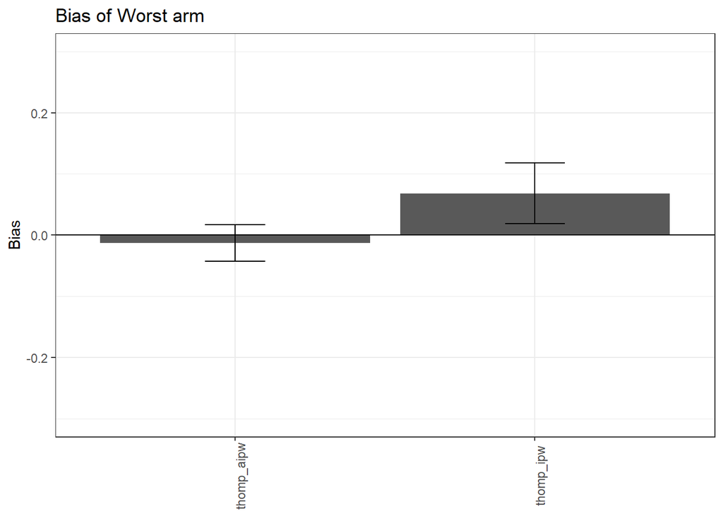

[figure not shown]

```
##
##  Shapiro-Wilk normality test
##
## data:  worst_thomp_ipw$mn
## W = 0.97337, p-value = 6.787e-08
```

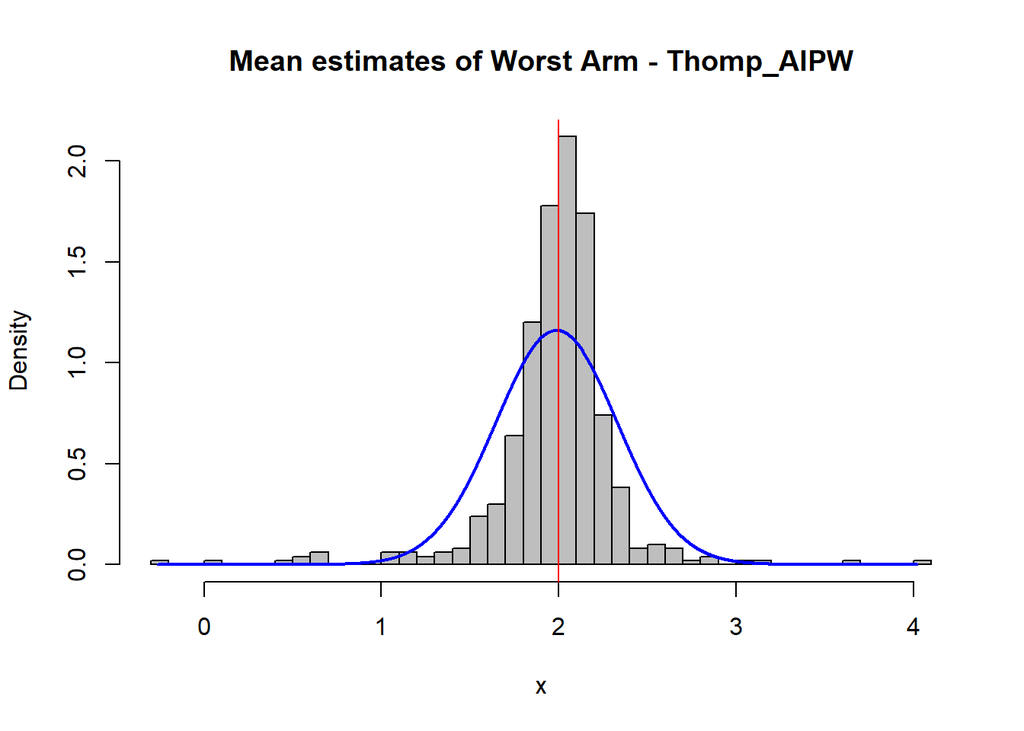

```
##
##  Shapiro-Wilk normality test
##
## data:  worst_thomp_aipw$mn
## W = 0.8143, p-value < 2.2e-16
```